# Module 7: Data visualization with ggplot2

ThuyTien Bui

17 April 2020

# 7 layers of graphics

| Layer | Description |
| --- | --- |
| Data | The dataframe being plotted |
| Aesthetic | The scales onto which we map our data. |
| Geometry | The visual elements (type of plot) used for our data. |
| Facet | Plotting small multiples. |
| Statistics | Representations of our data to aid understanding. |
| Coordinates | The space on which the data will be plotted. |
| Themes | All non-data ink. |

# GGplot2 layers - Data

# The Iris dataset

```r
# install.packages(tidyverse)
library(tidyverse)
library(gridExtra)
data(iris)
head(iris)
```

```
##   Sepal.Length Sepal.Width Petal.Length Petal.Width Species
## 1          5.1         3.5          1.4         0.2  setosa
## 2          4.9         3.0          1.4         0.2  setosa
## 3          4.7         3.2          1.3         0.2  setosa
## 4          4.6         3.1          1.5         0.2  setosa
## 5          5.0         3.6          1.4         0.2  setosa
## 6          5.4         3.9          1.7         0.4  setosa
```

```r
glimpse(iris)   # view the data frame
```

```
## Observations: 150
## Variables: 5
## $ Sepal.Length <dbl> 5.1, 4.9, 4.7, 4.6, 5.0, 5.4, 4.6, 5.0, 4.4, 4.9,...
## $ Sepal.Width  <dbl> 3.5, 3.0, 3.2, 3.1, 3.6, 3.9, 3.4, 3.4, 2.9, 3.1,...
## $ Petal.Length <dbl> 1.4, 1.4, 1.3, 1.5, 1.4, 1.7, 1.4, 1.5, 1.4, 1.5,...
## $ Petal.Width  <dbl> 0.2, 0.2, 0.2, 0.2, 0.2, 0.4, 0.3, 0.2, 0.2, 0.1,...
## $ Species      <fct> setosa, setosa, setosa, setosa, setosa, setosa, s...
```

# GGplot2 layers - Aesthetics

Mapping Sepal length to X axis and Sepal Width to Y axis

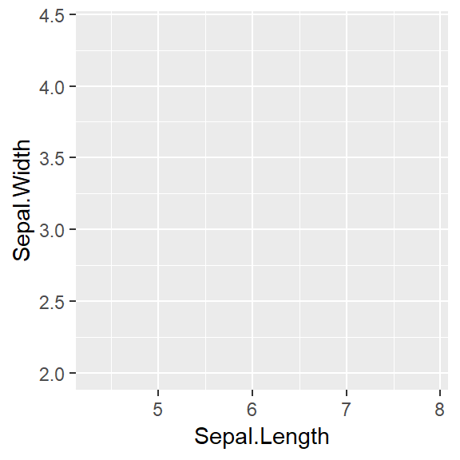

```r
g <- ggplot(data = iris, mapping = aes (x = Sepal.Length, y = Sepal.Width))
g
```

No plot produced yet !

# GGplot2 layers - Geometry

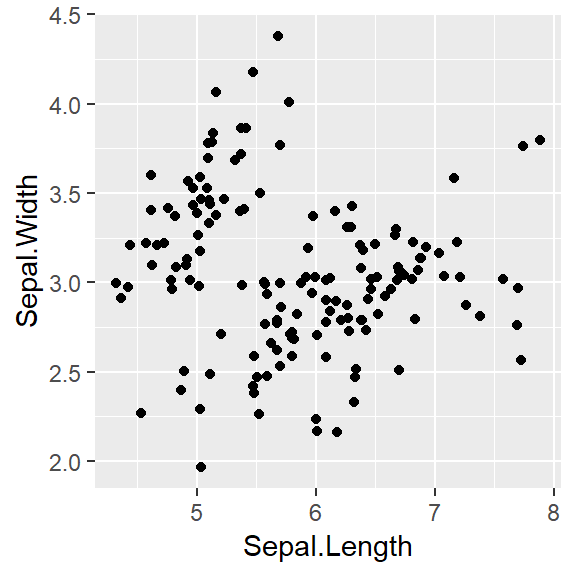

```r
g <- ggplot(data = iris, mapping = aes (x = Sepal.Length, y = Sepal.Width)) +
      geom_jitter()
g
```

# GGplot2 layers - Facet

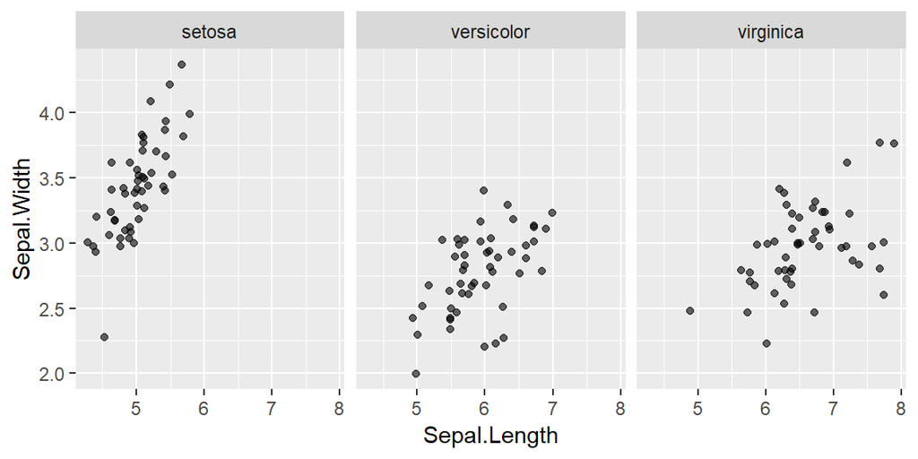

```r
g <- ggplot(data = iris, mapping = aes (x = Sepal.Length, y = Sepal.Width)) +
      geom_jitter(alpha = 0.6) +
      facet_grid(. ~ Species)
g
```

# GGplot2 layers - Statistics

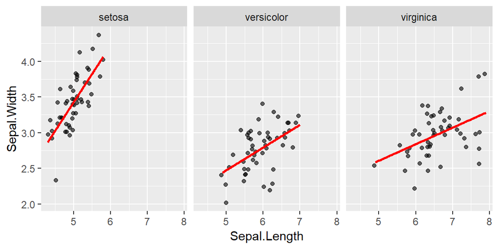

```r
g <- ggplot(data = iris, mapping = aes (x = Sepal.Length, y = Sepal.Width)) +
      geom_jitter(alpha = 0.6) +
      facet_grid(. ~ Species) +
      stat_smooth(method = "lm", se = F, col = "red")
g
```

# GGplot2 layers - Coordinates

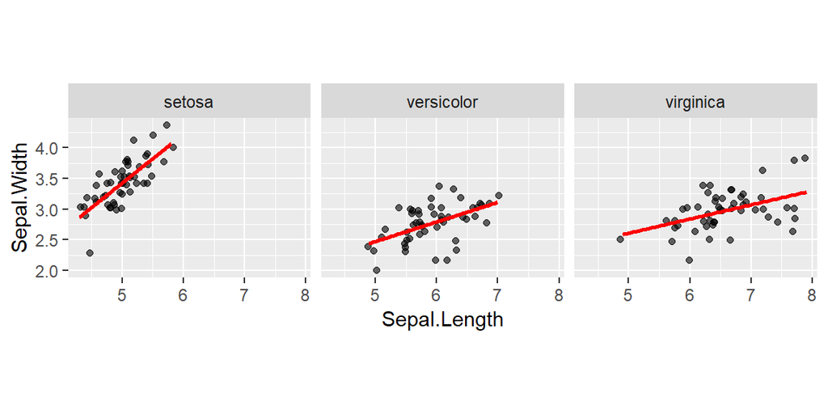

```r
g <- ggplot(data = iris, mapping = aes (x = Sepal.Length, y = Sepal.Width)) +
      geom_jitter(alpha = 0.6) +
      facet_grid(. ~ Species) +
      stat_smooth(method = "lm", se = F, col = "red") +
      coord_equal()
g
```

# GGplot2 layers - Themes

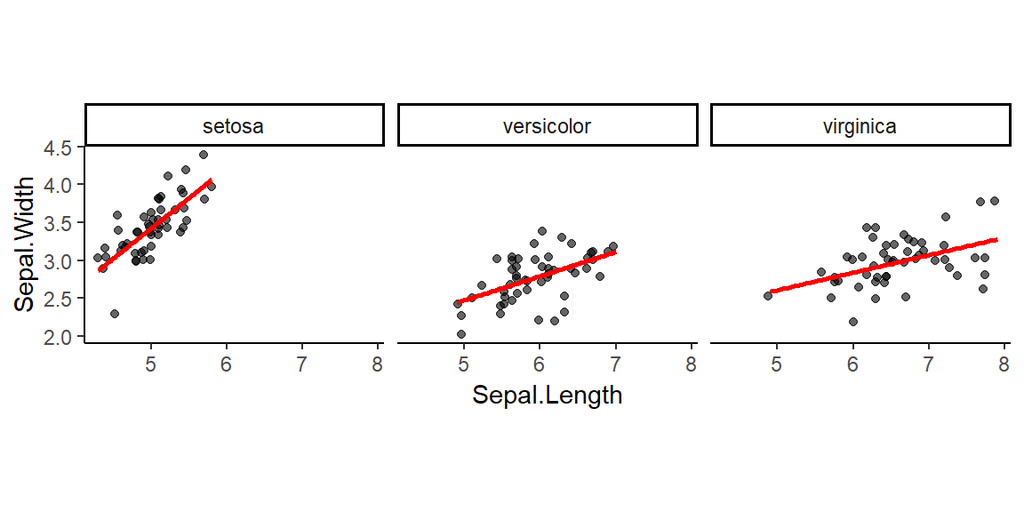

```r
g <- ggplot(data = iris, mapping = aes (x = Sepal.Length, y = Sepal.Width)) +
      geom_jitter(alpha = 0.6) +
      facet_grid(. ~ Species) +
      stat_smooth(method = "lm", se = F, col = "red") +
      coord_equal() +
      theme_classic()
g
```

# 7 layers of graphics

| Function | Returns |
| --- | --- |
| **Data** | The *dataframe* being plotted |
| **Aesthetic** | The scales onto which we map our data. |
| **Geometry** | The visual elements (type of plot) used for our data. |
| Facet | Plotting small multiples. |
| Statistics | Representations of our data to aid understanding. |
| Coordinates | The space on which the data will be plotted. |
| **Themes** | All non-data ink. |

In today’s session, I will go through the 4 elements: *Data*, *Aesthetic*, *Geometry*, and *Themes*.

The rest will be touch and go with examples

# Visible aesthetics

# Mapping onto the X and Y axes

Scatter plot between sepal width and length.

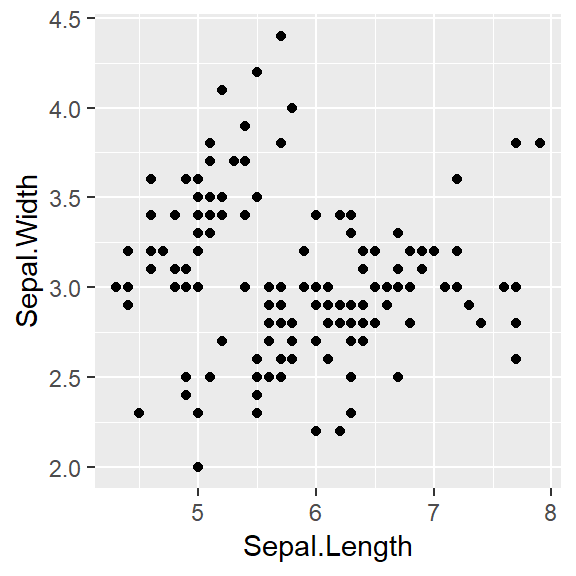

```r
g <- ggplot(data = iris, mapping = aes(x = Sepal.Length,
                                       y = Sepal.Width))+
        geom_point()
g
```

# Mapping onto colors

```r
unique(iris$Species)
```

```
## [1] setosa     versicolor virginica
## Levels: setosa versicolor virginica
```

Scatter plot between sepal width and length. Colored by species

```r
g <- ggplot(data = iris, mapping = aes(x = Sepal.Length,
                                       y = Sepal.Width,
                                       color = Species ))+
        geom_point()
g
```

[output not shown]

# Mapping onto colors aesthetics

Scatter plot between sepal width and length. Colored by species

```r
g <- ggplot(data = iris, mapping = aes(x = Sepal.Length,
                                       y = Sepal.Width,
                                       color = Species ))+
        geom_point()
g
```

[output not shown]

| Type | Variable |
| --- | --- |
| Color | Species |

**Species**, a dataframe column, is mapped onto color, a visible aesthetic.

# Mapping onto colors aesthetics in geom

Scatter plot between sepal width and length. Colored by species

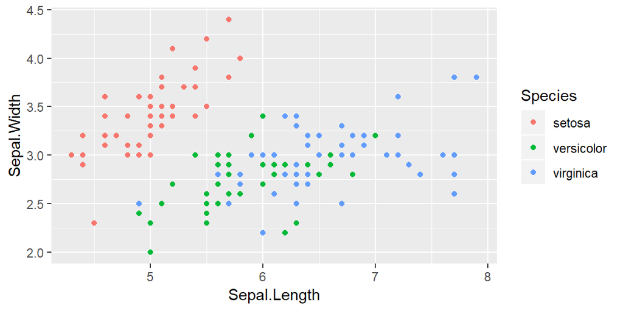

```r
g <- ggplot(data = iris) +
        geom_point(mapping = aes(x = Sepal.Length,
                                 y = Sepal.Width,
                                 color = Species ))
g
```

Only necessary if: * All layers should not inherit the same aesthetics * Mixing different data sources

# Typical visible aesthetics

| Aesthetic | Description |
| --- | --- |
| x | X axis position |
| y | Y axis position |
| fill | Fill color |
| color | Color of points, outlines of other geoms |
| size | Area or radius of points, thickness of lines |
| alpha | Transparency |
| linetype | line dash pattern |
| labels | Text on a plot or axes |
| shape | Shape |

# Using attributes - example

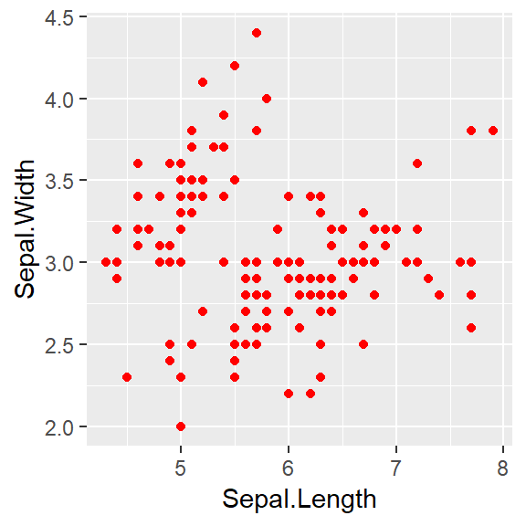

```r
g <- ggplot(data = iris, mapping = aes(x = Sepal.Length,
                                       y = Sepal.Width  )) +
        geom_point(color = "red")
g
```

The **color** attribute is set to **“red”** Attribute is set inside geom_*()

# Using attributes - another example

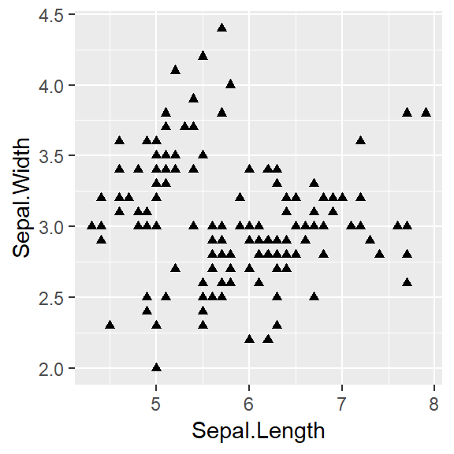

```r
g <- ggplot(data = iris, mapping = aes(x = Sepal.Length,
                                       y = Sepal.Width  )) +
        geom_point(shape = 17)
g
```

# Aesthetics? Attributes?

Aesthetics are defined inside aes() in ggplot syntax and attributes are outside the aes().

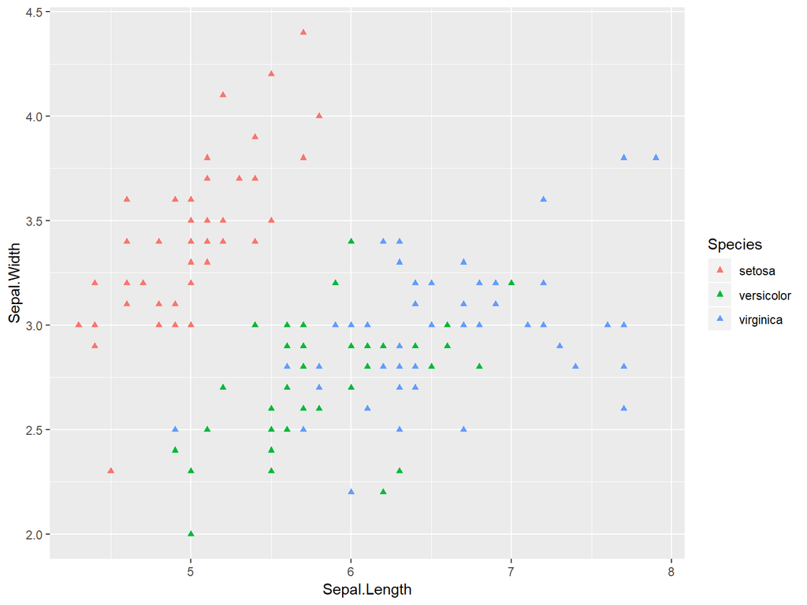

```r
g <- ggplot(data = iris, mapping = aes(x = Sepal.Length,
                                       y = Sepal.Width,
                                       color = Species)) +  # color mapped to Species variable
        geom_point(shape = 17)   # scatter dot size set at 10 unit, which is a constant
g
```

We typically understand aesthetics as how something looks, color, size etc. But in ggplot’s world how things look is just an attribute.

Aesthetics do not refer how something looks, but to which **variable**, or dataframe **column** is mapped onto it. Attributes refer to the property of the plot, and is set at a constant value (e.g `color = "red"`, or `shape = 17` )

# Appendix - scatter point shapes reference

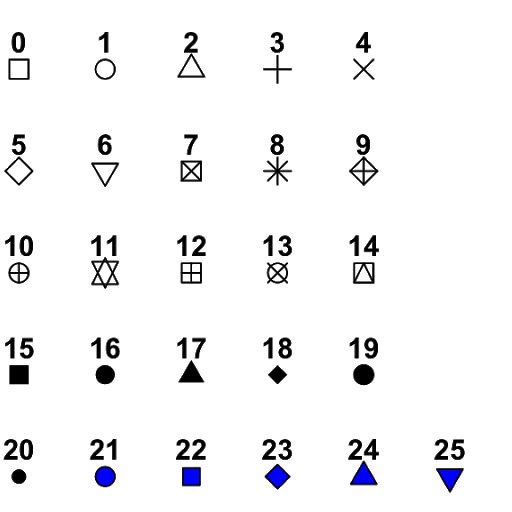

R scatter dot symbol

# Modifying aesthetics

Aesthetic mapping (i.e., with aes()) only says that a variable should be mapped to an aesthetic. It doesn’t say how that should happen. For example, when mapping a variable to shape with aes(shape = x) you don’t say what shapes should be used. Similarly, aes(color = z) doesn’t say what colors should be used. Describing what colors/shapes/sizes etc. to use is done by modifying the corresponding scale. In ggplot2 scales include: - position - color and fill - size - shape - line type

# Positions

Adjustment for overlapping: - identity - dodge - stack - fill - jitter - jitterdodge - nudge

# position = “identity” (default setting)

Let’s look at the dataframe again

```r
head(iris)
```

```
##   Sepal.Length Sepal.Width Petal.Length Petal.Width Species
## 1          5.1         3.5          1.4         0.2  setosa
## 2          4.9         3.0          1.4         0.2  setosa
## 3          4.7         3.2          1.3         0.2  setosa
## 4          4.6         3.1          1.5         0.2  setosa
## 5          5.0         3.6          1.4         0.2  setosa
## 6          5.4         3.9          1.7         0.4  setosa
```

```r
g <- ggplot(data = iris, mapping = aes(x = Sepal.Length,
                                       y = Sepal.Width,
                                       color = Species ))+
        geom_point()
g
```

[output not shown]

# position = “identity” (default setting)

```r
g <- ggplot(data = iris, mapping = aes(x = Sepal.Length,
                                       y = Sepal.Width,
                                       color = Species ))+
        geom_point(position = "identity")
g
```

[output not shown]

# position = “jitter”

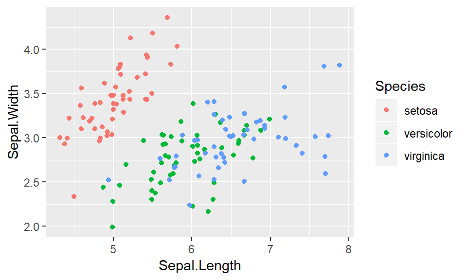

```r
g <- ggplot(data = iris, mapping = aes(x = Sepal.Length,
                                       y = Sepal.Width,
                                       color = Species ))+
        geom_point(position = "jitter")
g
```

`position = "jitter"` adds noise to the scatter plot.

# Control level of noise added by position_jitter()

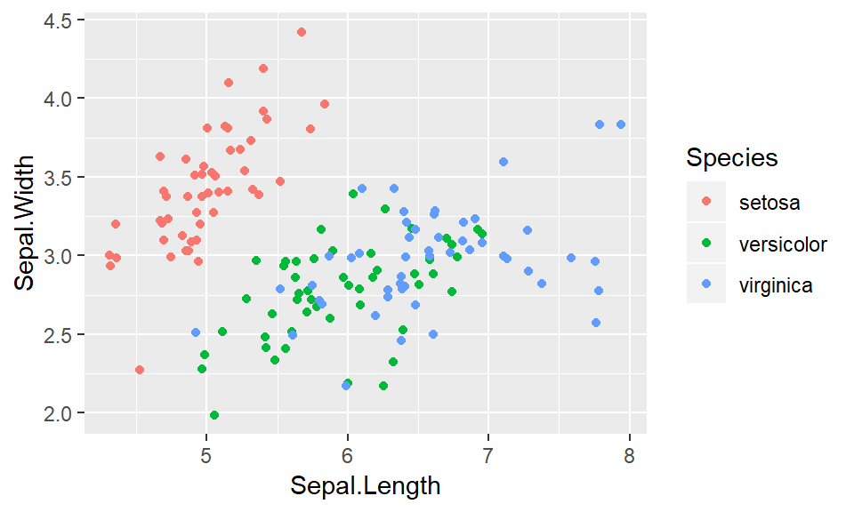

```r
posn_j <- position_jitter(0.1, seed = 136)   # set the seed for consistency between different runs
g <- ggplot(data = iris, mapping = aes(x = Sepal.Length,
                                       y = Sepal.Width,
                                       color = Species ))+
        geom_point(position = posn_j)
g
```

# Scale functions

- scale_x_*()
- scale_y_*()
- scale_color_*()
- scale_fill_*()
- scale_shape_*()
- scale_linetype_*()
- scale_size_*()

# scale_…_…() functions - examples

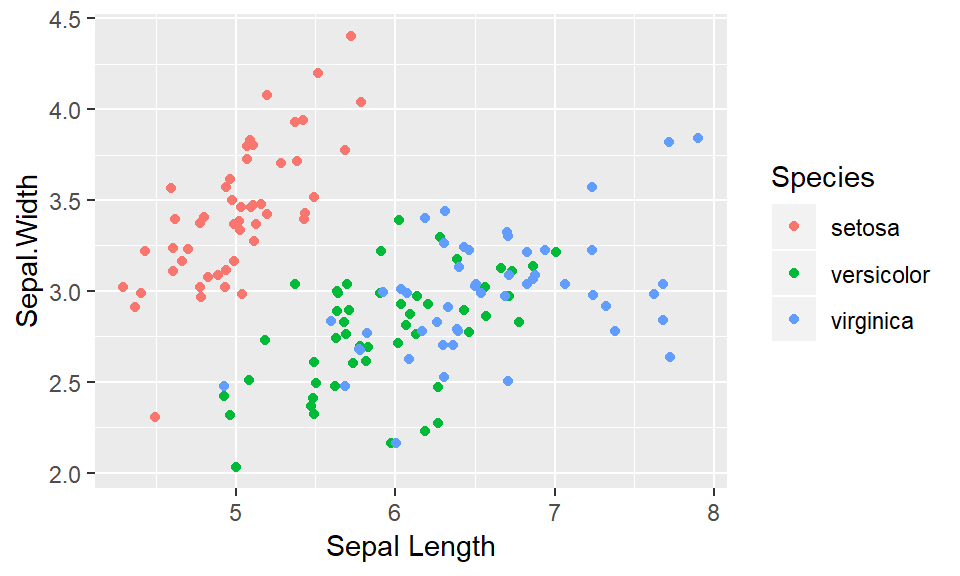

```r
g <- ggplot(data = iris, mapping = aes(x = Sepal.Length,
                                       y = Sepal.Width,
                                       color = Species )) +
        geom_point(position = "jitter") +
        scale_x_continuous("Sepal Length") +
        scale_color_discrete("Species")
g
```

# The limit argument

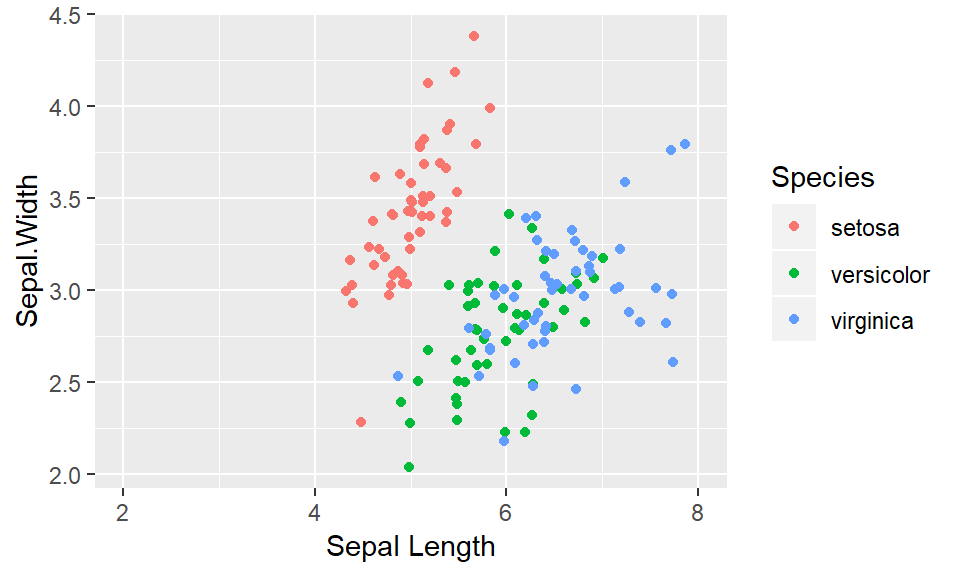

```r
g <- ggplot(data = iris, mapping = aes(x = Sepal.Length,
                                       y = Sepal.Width,
                                       color = Species )) +
        geom_point(position = "jitter") +
        scale_x_continuous("Sepal Length", limits = c(2, 8)) +
        scale_color_discrete("Species")
g
```

# The breaks argument

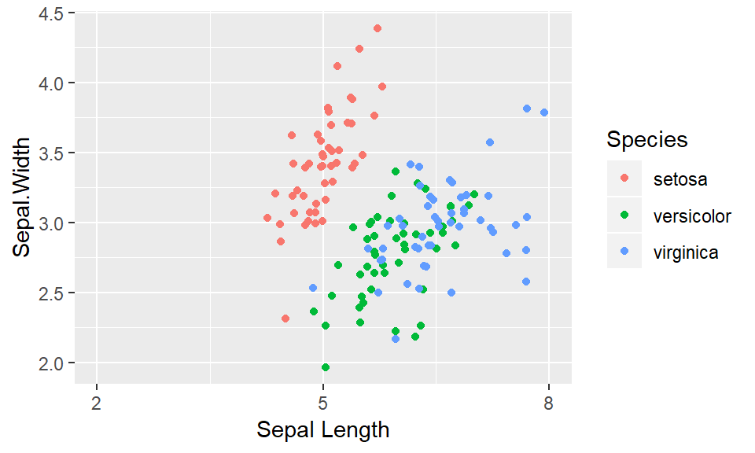

```r
g <- ggplot(data = iris, mapping = aes(x = Sepal.Length,
                                       y = Sepal.Width,
                                       color = Species )) +
        geom_point(position = "jitter") +
        scale_x_continuous("Sepal Length", limits = c(2, 8),
                           breaks = seq(2, 8, 3)) +
        scale_color_discrete("Species")
g
```

# The expand argument

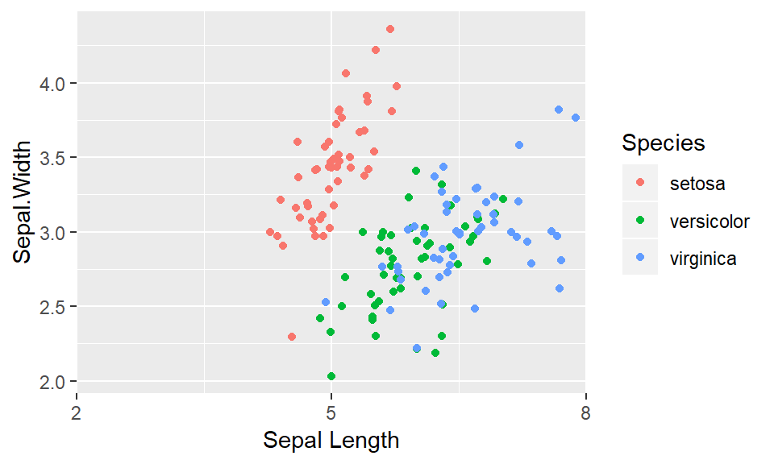

```r
g <- ggplot(data = iris, mapping = aes(x = Sepal.Length,
                                       y = Sepal.Width,
                                       color = Species )) +
        geom_point(position = "jitter") +
        scale_x_continuous("Sepal Length", limits = c(2, 8),
                           breaks = seq(2, 8, 3), expand=c(0,0) ) +
        scale_color_discrete("Species")
g
```

# The labels argument

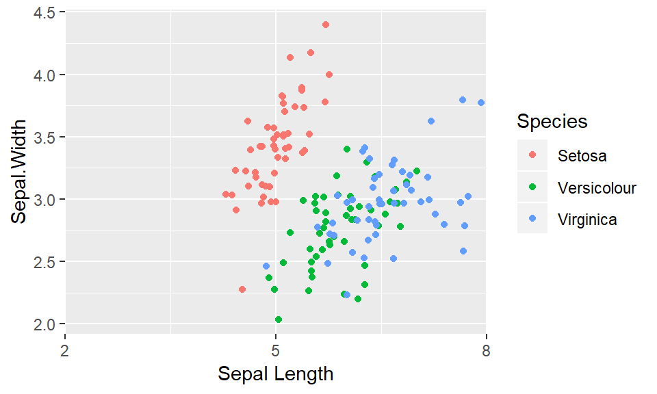

```r
g <- ggplot(data = iris, mapping = aes(x = Sepal.Length,
                                       y = Sepal.Width,
                                       color = Species )) +
        geom_point(position = "jitter") +
        scale_x_continuous("Sepal Length", limits = c(2, 8),
                           breaks = seq(2, 8, 3), expand=c(0,0) ) +
        scale_color_discrete("Species",
                             labels = c("Setosa", "Versicolour", "Virginica") )
g
```

# Geom layer

48 geometries geom_*

abline contour dotplot jitter pointrange ribbon spoke area count errorbar label polygon rug step bar crossbar errorbarh line qq segment text bin2d curve freqpoly linerange qq_line sf tile blank density hex map quantile sf_label violin boxplot density2d histogram path raster sf_text vline col density_2d hline point rect smooth

# Common plot types

| Plot type | Possible geom_ |
| --- | --- |
| **Scatter plot** | **points, jitter, abline, smooth, count** |
| Bar plot | histogram, bar, col, errorbar |
| Line plot | line, path |

# Scatter plots

Each geom can accept specific mappings. For geom_point: Essential mappings: x, y Optional mapping: alpha, color, fill, shape, size, stroke

# Geom-specific aesthetic mappings

```r
# These result in the same plot!
ggplot(iris, aes(x = Sepal.Length, y = Sepal.Width, col = Species)) +
  geom_point()
```

Control aesthetic mappings of each layer independently:

```r
# These result in the same plot!
ggplot(iris, aes(x = Sepal.Length, y = Sepal.Width)) +
  geom_point(aes(col = Species))
```

# Inherited aes

```r
head(iris, 3) # Raw data
```

```
##   Sepal.Length Sepal.Width Petal.Length Petal.Width Species
## 1          5.1         3.5          1.4         0.2  setosa
## 2          4.9         3.0          1.4         0.2  setosa
## 3          4.7         3.2          1.3         0.2  setosa
```

```r
iris %>%
  group_by(Species) %>%
  summarise_all(mean) -> iris.summary

iris.summary # Summary statistics
```

```
## # A tibble: 3 x 5
##   Species    Sepal.Length Sepal.Width Petal.Length Petal.Width
##   <fct>             <dbl>       <dbl>        <dbl>       <dbl>
## 1 setosa             5.01        3.43         1.46       0.246
## 2 versicolor         5.94        2.77         4.26       1.33
## 3 virginica          6.59        2.97         5.55       2.03
```

# Inherited aes

Both data and aes are inherited from ggplot() in geom_* layer When data mapping is updated, the remaining aes mapping remains

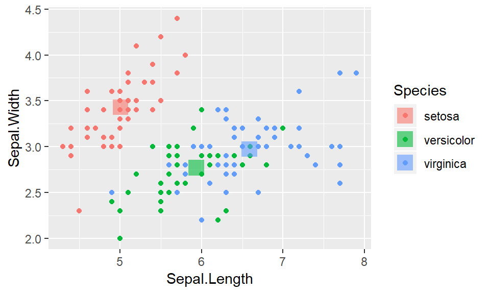

```r
g <- ggplot(iris, aes(x = Sepal.Length, y = Sepal.Width, col = Species)) +
      # Inherits both data and aes from ggplot()
      geom_point() +
      # Different data, but inherited aes
      geom_point(data = iris.summary, shape = 15, size = 5, alpha = 0.6) # alpha = transparency
g
```

# Bar plot

### Commmon plot types

| Plot type | Possible geom_ |
| --- | --- |
| Scatter plot | points, jitter, abline, smooth, count |
| **Bar plot** | **histogram, bar, col, errorbar** |
| Line plot | line, path |

# Histogram - default values

Default number of bins is 30. We can pick better bin value by setting `binwidth` or `bins`

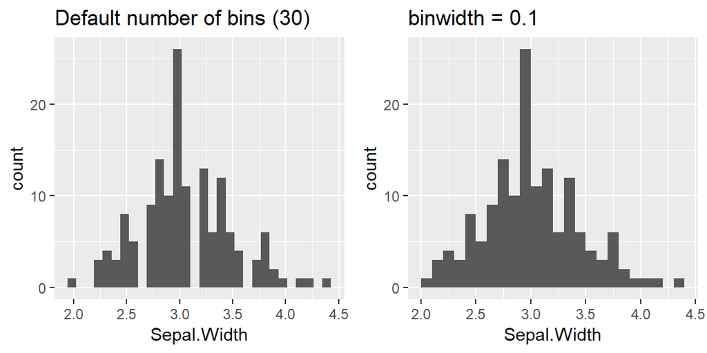

```r
g1 <- ggplot(iris, aes(x = Sepal.Width)) +
        geom_histogram() +
        ggtitle("Default number of bins (30)")

g2 <- ggplot(iris, aes(x = Sepal.Width)) +
        geom_histogram(binwidth = 0.1, center = 0.05) +
        ggtitle("binwidth = 0.1")

grid.arrange(g1, g2, nrow = 1)
```

# Multiple histograms - example with different species

Default position is “stack” #### Problems?

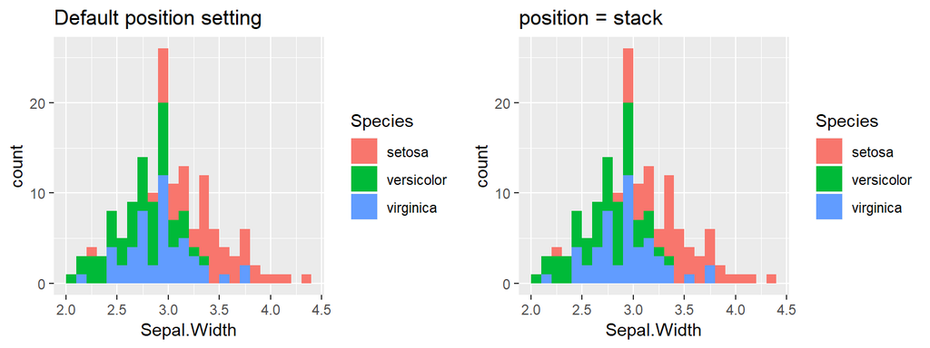

```r
g1 <- ggplot(iris, aes(x = Sepal.Width, fill = Species)) +
      geom_histogram(binwidth = 0.1, center = 0.05) +
      ggtitle("Default position setting")

g2 <- ggplot(iris, aes(x = Sepal.Width, fill = Species)) +
      geom_histogram(binwidth = 0.1, center = 0.05, positiobn = "stack") +
      ggtitle("position = stack")
grid.arrange(g1, g2, nrow = 1)
```

We cant say whether the histogram bars are stacked or overlapped onto each other

# Solution: position = “dodge” and position = “fill”

Question: Why dont we use position = “identity”?

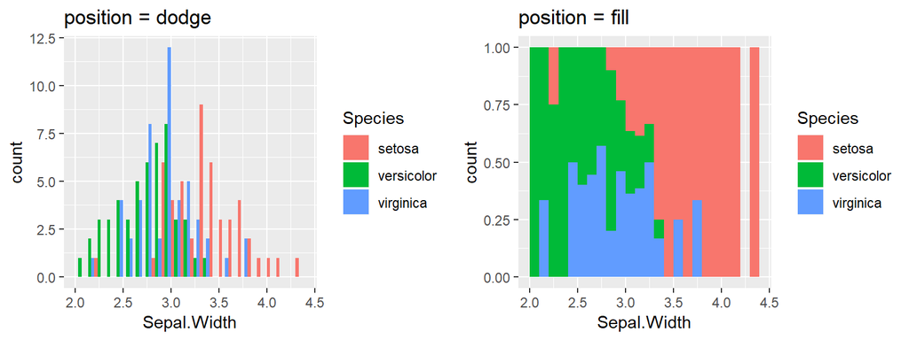

```r
g1 <- ggplot(iris, aes(x = Sepal.Width, fill = Species)) +
        geom_histogram(binwidth = 0.1, center = 0.05, position = "dodge") +
        ggtitle("position = dodge")
g2 <- ggplot(iris, aes(x = Sepal.Width, fill = Species)) +
        geom_histogram(binwidth = 0.1, center = 0.05, position = "fill") +
        ggtitle("position = fill")
grid.arrange(g1, g2, nrow = 1)
```

# To avoid: position = “identity”

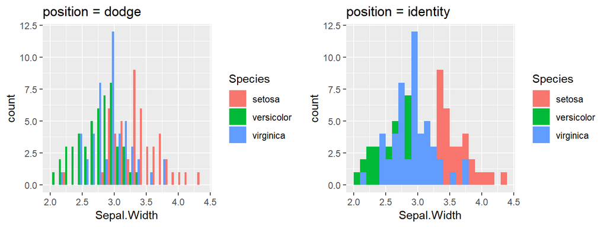

```r
g1 <- ggplot(iris, aes(x = Sepal.Width, fill = Species)) +
        geom_histogram(binwidth = 0.1, center = 0.05, position = "dodge") +
        ggtitle("position = dodge")
g2 <- ggplot(iris, aes(x = Sepal.Width, fill = Species)) +
        geom_histogram(binwidth = 0.1, center = 0.05, position = "identity") +
        ggtitle("position = identity")
grid.arrange(g1, g2, nrow = 1)
```

# Bar plot, with a categorical X-axis

- Use geom_bar or geom_col
- All positions from before are available
- Two types:
  - Absolute counts
  - Distribution

| Geom | Stat | Action |
| --- | --- | --- |
| geom_bar() | “count” | Counts the number of cases at each x position |
| geom_col() | “identity” | Plot actual values |

# Barplot - absolute count

```r
head(iris)
```

```
##   Sepal.Length Sepal.Width Petal.Length Petal.Width Species
## 1          5.1         3.5          1.4         0.2  setosa
## 2          4.9         3.0          1.4         0.2  setosa
## 3          4.7         3.2          1.3         0.2  setosa
## 4          4.6         3.1          1.5         0.2  setosa
## 5          5.0         3.6          1.4         0.2  setosa
## 6          5.4         3.9          1.7         0.4  setosa
```

```r
summary(iris)
```

```
##   Sepal.Length    Sepal.Width     Petal.Length    Petal.Width
##  Min.   :4.300   Min.   :2.000   Min.   :1.000   Min.   :0.100
##  1st Qu.:5.100   1st Qu.:2.800   1st Qu.:1.600   1st Qu.:0.300
##  Median :5.800   Median :3.000   Median :4.350   Median :1.300
##  Mean   :5.843   Mean   :3.057   Mean   :3.758   Mean   :1.199
##  3rd Qu.:6.400   3rd Qu.:3.300   3rd Qu.:5.100   3rd Qu.:1.800
##  Max.   :7.900   Max.   :4.400   Max.   :6.900   Max.   :2.500
##        Species
##  setosa    :50
##  versicolor:50
##  virginica :50
##
##
##
```

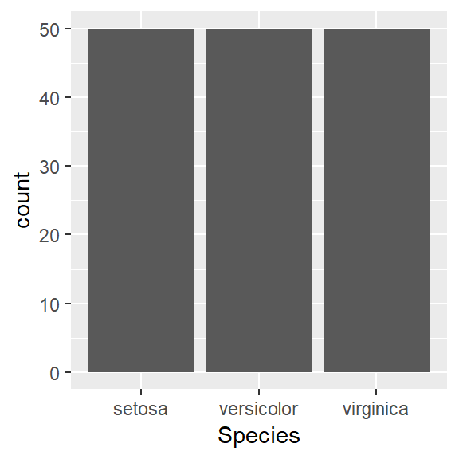

```r
ggplot(iris, aes(x=Species)) +
  geom_bar()
```

# Plotting distributions - adding decriptive statistics

```r
# Calculate Descriptive Statistics:
sepal_width_summary <- iris %>%
                        select(Species, Sepal.Width) %>%
                        gather(key, value, -Species) %>%
                        group_by(Species) %>%
                        summarise(avg = mean(value),
                        stdev = sd(value))
```

# Adding error bar

To be continued at stat_* layer

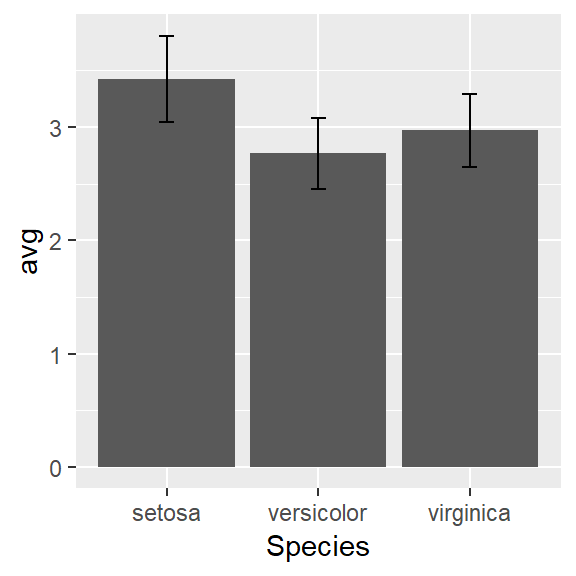

```r
# Calculate Descriptive Statistics:
ggplot(sepal_width_summary, aes(x = Species, y = avg)) +
  geom_col() +
  geom_errorbar(aes(ymin = avg - stdev, ymax = avg + stdev),
  width = 0.1)
```

# Histogram is basically bar plot

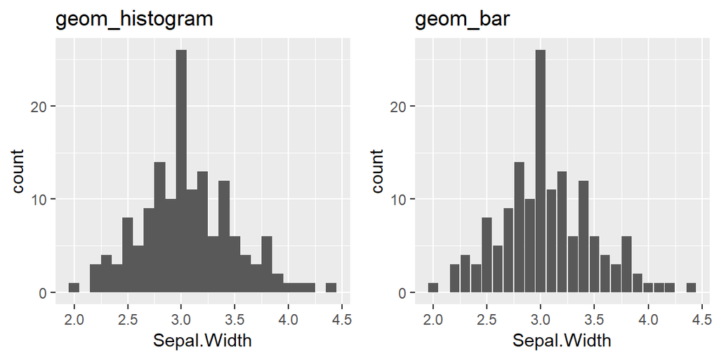

```r
g1 <- ggplot(iris, aes(x = Sepal.Width)) +
        geom_histogram(binwidth = 0.1) +
        ggtitle("geom_histogram")

g2 <- ggplot(iris, aes(x = Sepal.Width)) +
        geom_bar() +
        ggtitle("geom_bar")

grid.arrange(g1, g2, nrow = 1)
```

# Line plot (skipped)

### Commmon plot types

| Plot type | Possible geom_ |
| --- | --- |
| Scatter plot | points, jitter, abline, smooth, count |
| Bar plot | histogram, bar, col, errorbar** |
| **Line plot** | **line, path** |

# Examples with economics data set

unemployment and population statistics from the Federal Reserve Bank of St. Louis in the US. The data is contained in the ggplot2 package.

```r
data(economics)
head(economics)
```

```
## # A tibble: 6 x 6
##   date         pce    pop psavert uempmed unemploy
##   <date>     <dbl>  <int>   <dbl>   <dbl>    <int>
## 1 1967-07-01  507. 198712    12.5     4.5     2944
## 2 1967-08-01  510. 198911    12.5     4.7     2945
## 3 1967-09-01  516. 199113    11.7     4.6     2958
## 4 1967-10-01  513. 199311    12.5     4.9     3143
## 5 1967-11-01  518. 199498    12.5     4.7     3066
## 6 1967-12-01  526. 199657    12.1     4.8     3018
```

```r
str(economics)
```

```
## Classes 'tbl_df', 'tbl' and 'data.frame':    574 obs. of  6 variables:
##  $ date    : Date, format: "1967-07-01" "1967-08-01" ...
##  $ pce     : num  507 510 516 513 518 ...
##  $ pop     : int  198712 198911 199113 199311 199498 199657 199808 199920 200056 200208 ...
##  $ psavert : num  12.5 12.5 11.7 12.5 12.5 12.1 11.7 12.2 11.6 12.2 ...
##  $ uempmed : num  4.5 4.7 4.6 4.9 4.7 4.8 5.1 4.5 4.1 4.6 ...
##  $ unemploy: int  2944 2945 2958 3143 3066 3018 2878 3001 2877 2709 ...
```

Note: The `date` column is formatted as `Date`. This data type becomes handy when dealing with date, or date/time data. For converting data to `Date` formate, check out `as.Date`

# Examples with economics data set

Line plot showing the fraction of total population that is unemployed

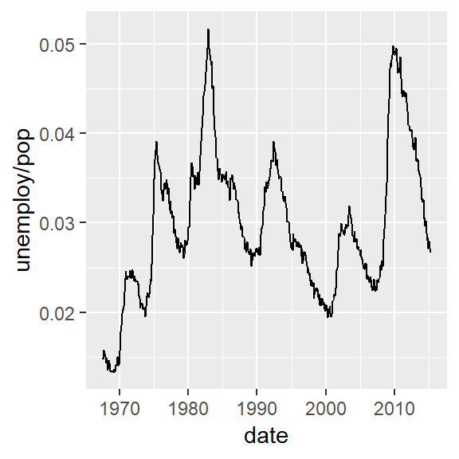

```r
ggplot(economics, aes(x = date, y = unemploy/pop)) + # get fraction of total population that is unemployed
  geom_line()
```

# Periods of recession

In addition to the economics dataset from before, you’ll also use the recess dataset for the periods of recession. The recess data frame contains 2 variables: the begin period of the recession and the end. It’s already available in your workspace.

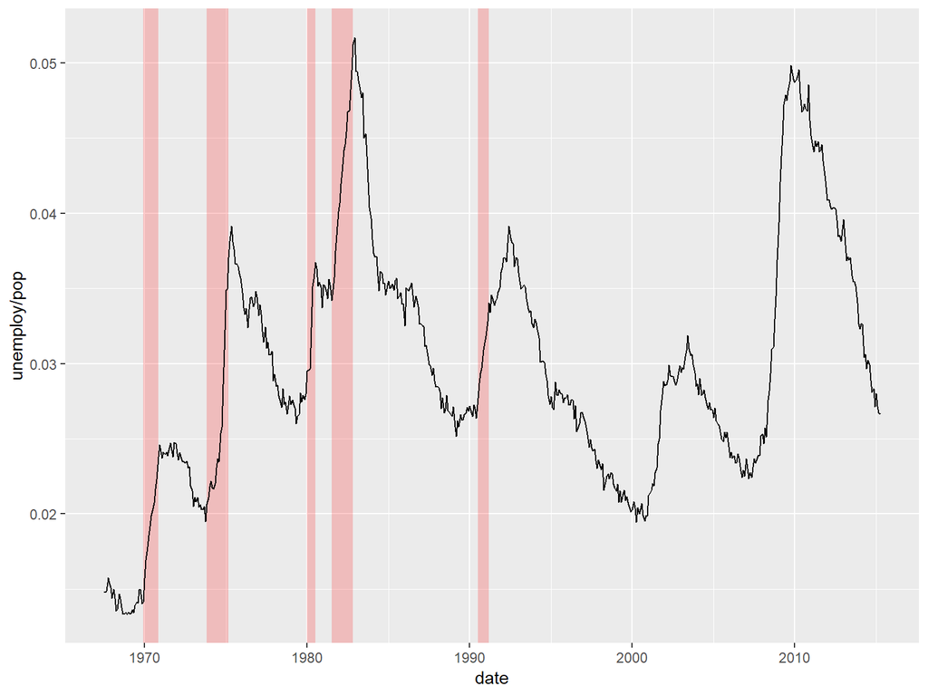

```r
recess <- data.frame(begin = as.Date(c("1969-12-01","1973-11-01","1980-01-01","1981-07-01","1990-07-01")),
                     end   = as.Date(c("1970-11-01","1975-03-01","1980-07-01","1982-11-01","1991-03-01")))


ggplot(economics, aes(x = date, y = unemploy/pop)) +
  geom_rect(data = recess,
            aes(xmin = begin, xmax = end, ymin = -Inf, ymax = +Inf),
            inherit.aes = FALSE, fill = "red", alpha = 0.2) +
  geom_line()
```

# Statistics layler

Two categories of functions - Called from within a geom - Called independently Can be accessed via stat_*

# Statistics with Geoms - histogram count

Another way to do histogram plot ! All methods count the time a specific sepal width value appears

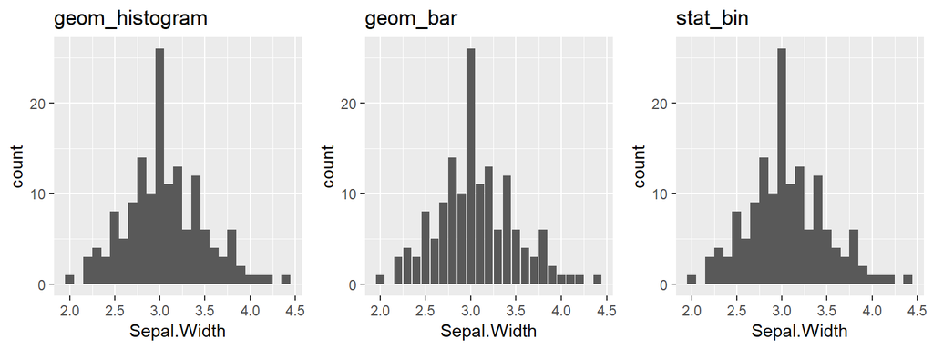

```r
g <- ggplot(iris, aes(x = Sepal.Width))
g1 <- g +
        geom_histogram(binwidth = 0.1) +
        ggtitle("geom_histogram")

g2 <- g +
        geom_bar(stat = "count") +
        ggtitle("geom_bar")

g3 <- g +
        stat_bin(binwidth = 0.1) +
        ggtitle("stat_bin")

grid.arrange(g1, g2, g3, nrow = 1)
```

# Statistics with geom - smoothing

stat_smooth can be accessed with geom_smooth Standard error is showed as the grey ribbon behind each smoothing line. It is 5% confident interval by default

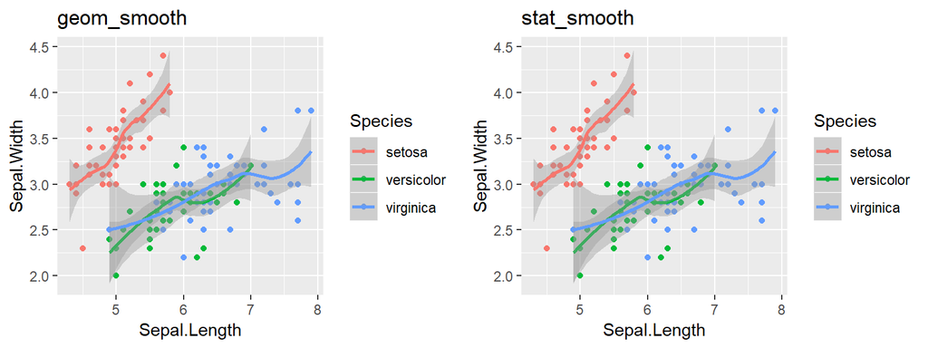

```r
g <- ggplot(iris, aes(x = Sepal.Length, y = Sepal.Width, col = Species)) +
        geom_point()

g1 <- g + geom_smooth() + ggtitle("geom_smooth")

g2 <- g + stat_smooth() + ggtitle("stat_smooth")

grid.arrange(g1, g2, nrow = 1)
```

Note: By default, loess regression is used. It is a non-parametric methods where least squares regression is performed in localized subsets, and used when n < 1000. We can change smoothing method with the `method` argument

# More arguments with smoothing!

`se = FALSE` turns off the ribbon (5% confident interval by default) *span* argument controls the degree of smoothing (size of sliding window in loess) *method* argument controls smoothing method

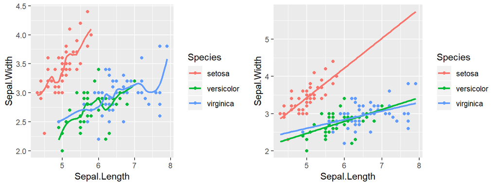

```r
g <- ggplot(iris, aes(x = Sepal.Length, y = Sepal.Width, col = Species)) +
        geom_point()

g1 <- g + stat_smooth(se = FALSE,
                      span = 0.4)

g2 <- g + stat_smooth(se = FALSE,
                      method = "glm",
                      fullrange = TRUE )

grid.arrange(g1, g2, nrow = 1)
```